# Clinical Trial Efficacy and Safety: Synthetic Demonstration

Independent biostatistics portfolio project

October 31, 2026

> **Synthetic data only.** The participants, intervention, measurements and adverse events are completely fictional. Nothing in this report supports clinical decisions or real-world safety/efficacy claims.

# Study overview

We modeled a hypothetical 12-week, two-arm, randomized experiment of a symptom burden score (0–100; **lower is better**). This document illustrates reproducible statistical analysis and reporting; it is not a real clinical investigation.

There are 600 randomized participants across 6 simulated sites. 40 week-12 outcome values are missing.

# Efficacy analysis

Primary exploratory model: ANCOVA for the week-12 score, adjusted for randomized arm, baseline score, age, sex, and site. The effect estimate is **Treatment minus Control**.

Observed-case summaries and missing outcomes

| arm | randomized_n | missing_week12_n | mean_baseline | mean_week12 | mean_change | responders_n | responder_rate |
| --- | --- | --- | --- | --- | --- | --- | --- |
| Control | 300 | 15 | 65.201 | 56.799 | -8.482 | 106 | 0.372 |
| Treatment | 300 | 25 | 64.881 | 52.139 | -12.551 | 145 | 0.527 |

Adjusted continuous endpoint

| analysis | n_analyzed | effect | ci_lower | ci_upper | p_value |
| --- | --- | --- | --- | --- | --- |
| Observed-case ANCOVA | 560 | -4.0885 | -5.6348 | -2.5423 | p < 0.0001 |

Adjusted responder odds ratio (exploratory)

| analysis | n_analyzed | odds_ratio | ci_lower | ci_upper | p_value |
| --- | --- | --- | --- | --- | --- |
| Observed-case adjusted responder odds ratio | 560 | 1.9348 | 1.3713 | 2.7298 | 0.0002 |

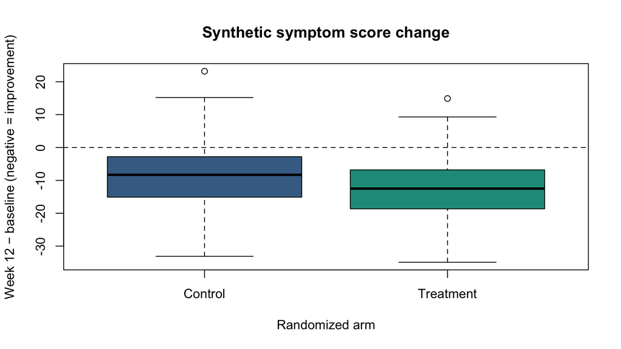

# Missing-data sensitivity

The primary analysis excludes unobserved week-12 scores. The sensitivity analysis substitutes baseline for missing week-12 scores (a *no-improvement* assumption). This simplistic method may be biased and is not a replacement for multiple imputation or formal estimand sensitivity analyses.

| analysis | n_analyzed | effect | ci_lower | ci_upper | p_value |
| --- | --- | --- | --- | --- | --- |
| Baseline observation carried forward (sensitivity) | 600 | -3.4938 | -5.0004 | -1.9871 | p < 0.0001 |

# Safety analysis

Safety summaries use all randomized simulated participants. Rates and Wilson intervals are descriptive; sparse event comparisons should be interpreted cautiously.

Adverse-event frequency and Wilson 95% intervals

| event | arm | events_n | total_n | risk | risk_ci_lower | risk_ci_upper |
| --- | --- | --- | --- | --- | --- | --- |
| Any reported AE | Control | 92 | 300 | 0.307 | 0.257 | 0.361 |
| Any reported AE | Treatment | 123 | 300 | 0.410 | 0.356 | 0.466 |
| Serious AE | Control | 4 | 300 | 0.013 | 0.005 | 0.034 |
| Serious AE | Treatment | 4 | 300 | 0.013 | 0.005 | 0.034 |
| Headache | Control | 29 | 300 | 0.097 | 0.068 | 0.135 |
| Headache | Treatment | 47 | 300 | 0.157 | 0.120 | 0.202 |
| Nausea | Control | 27 | 300 | 0.090 | 0.063 | 0.128 |
| Nausea | Treatment | 39 | 300 | 0.130 | 0.097 | 0.173 |
| Fatigue | Control | 44 | 300 | 0.147 | 0.111 | 0.191 |
| Fatigue | Treatment | 35 | 300 | 0.117 | 0.085 | 0.158 |
| Rash | Control | 8 | 300 | 0.027 | 0.014 | 0.052 |
| Rash | Treatment | 29 | 300 | 0.097 | 0.068 | 0.135 |

Exploratory crude comparison for any adverse event

| endpoint | treatment_risk | control_risk | risk_difference | risk_ratio | fisher_p_value |
| --- | --- | --- | --- | --- | --- |
| Any reported AE | 0.41 | 0.3067 | 0.1033 | 1.337 | 0.0106 |

# Monte Carlo operating characteristics

The following scenario analysis repeatedly simulates a simple ANCOVA model and estimates the proportion of p-values below 0.05. The Monte Carlo standard error quantifies uncertainty from the **number of simulation repetitions**.

| n_per_arm | treatment_effect | outcome_sd | replications | alpha | rejection_rate | mc_se |
| --- | --- | --- | --- | --- | --- | --- |
| 300 | 0.0 | 9 | 200 | 0.05 | 0.040 | 0.0139 |
| 300 | -2.5 | 9 | 200 | 0.05 | 0.935 | 0.0174 |
| 300 | -4.5 | 9 | 200 | 0.05 | 1.000 | 0.0000 |

# Limitations

This is **not patient data**. Effects are implanted into the simulated data-generating mechanism. The complete-case analysis, BOCF sensitivity, simplistic adverse-event indicators and short follow-up do not satisfy standards for confirmatory clinical trial inference. See `docs/analysis_plan.md` for assumptions and planned improvements.